# WageAnalysisWithQuantileReg

Duc-Anh Nguyen

2025-02-04

This dataset from the ISLR package contains information about yearly incomes of 3,000 male workers in the Mid-Atlantic region of the United States.

####Goal: model yearly income as a function of age and education.

### EDA

```r
# Load the necessary packages
#install.packages("ISLR")
library(ISLR)
```

```r
library(ggplot2)
library(dplyr)
# Load and clean the data
data("Wage")
wage  <-  Wage
dim(wage)
```

```
## [1] 3000   11
```

```r
wage |> head()
```

```
##        year age           maritl     race       education             region
## 231655 2006  18 1. Never Married 1. White    1. < HS Grad 2. Middle Atlantic
## 86582  2004  24 1. Never Married 1. White 4. College Grad 2. Middle Atlantic
## 161300 2003  45       2. Married 1. White 3. Some College 2. Middle Atlantic
## 155159 2003  43       2. Married 3. Asian 4. College Grad 2. Middle Atlantic
## 11443  2005  50      4. Divorced 1. White      2. HS Grad 2. Middle Atlantic
## 376662 2008  54       2. Married 1. White 4. College Grad 2. Middle Atlantic
##              jobclass         health health_ins  logwage      wage
## 231655  1. Industrial      1. <=Good      2. No 4.318063  75.04315
## 86582  2. Information 2. >=Very Good      2. No 4.255273  70.47602
## 161300  1. Industrial      1. <=Good     1. Yes 4.875061 130.98218
## 155159 2. Information 2. >=Very Good     1. Yes 5.041393 154.68529
## 11443  2. Information      1. <=Good     1. Yes 4.318063  75.04315
## 376662 2. Information 2. >=Very Good     1. Yes 4.845098 127.11574
```

```r
skimr::skim(wage)
```

Data summary

| Name | wage |
| --- | --- |
| Number of rows | 3000 |
| Number of columns | 11 |
| _______________________ |  |
| Column type frequency: |  |
| factor | 7 |
| numeric | 4 |
| ________________________ |  |
| Group variables | None |

**Variable type: factor**

| skim_variable | n_missing | complete_rate | ordered | n_unique | top_counts |
| --- | --- | --- | --- | --- | --- |
| maritl | 0 | 1 | FALSE | 5 | 2. : 2074, 1. : 648, 4. : 204, 5. : 55 |
| race | 0 | 1 | FALSE | 4 | 1. : 2480, 2. : 293, 3. : 190, 4. : 37 |
| education | 0 | 1 | FALSE | 5 | 2. : 971, 4. : 685, 3. : 650, 5. : 426 |
| region | 0 | 1 | FALSE | 1 | 2. : 3000, 1. : 0, 3. : 0, 4. : 0 |
| jobclass | 0 | 1 | FALSE | 2 | 1. : 1544, 2. : 1456 |
| health | 0 | 1 | FALSE | 2 | 2. : 2142, 1. : 858 |
| health_ins | 0 | 1 | FALSE | 2 | 1. : 2083, 2. : 917 |

**Variable type: numeric**

| skim_variable | n_missing | complete_rate | mean | sd | p0 | p25 | p50 | p75 | p100 | hist |
| --- | --- | --- | --- | --- | --- | --- | --- | --- | --- | --- |
| year | 0 | 1 | 2005.79 | 2.03 | 2003.00 | 2004.00 | 2006.00 | 2008.00 | 2009.00 | ▇▃▃▃▆ |
| age | 0 | 1 | 42.41 | 11.54 | 18.00 | 33.75 | 42.00 | 51.00 | 80.00 | ▃▇▇▃▁ |
| logwage | 0 | 1 | 4.65 | 0.35 | 3.00 | 4.45 | 4.65 | 4.86 | 5.76 | ▁▁▇▇▁ |
| wage | 0 | 1 | 111.70 | 41.73 | 20.09 | 85.38 | 104.92 | 128.68 | 318.34 | ▂▇▂▁▁ |

```r
wage|> str()
```

```
## 'data.frame':    3000 obs. of  11 variables:
##  $ year      : int  2006 2004 2003 2003 2005 2008 2009 2008 2006 2004 ...
##  $ age       : int  18 24 45 43 50 54 44 30 41 52 ...
##  $ maritl    : Factor w/ 5 levels "1. Never Married",..: 1 1 2 2 4 2 2 1 1 2 ...
##  $ race      : Factor w/ 4 levels "1. White","2. Black",..: 1 1 1 3 1 1 4 3 2 1 ...
##  $ education : Factor w/ 5 levels "1. < HS Grad",..: 1 4 3 4 2 4 3 3 3 2 ...
##  $ region    : Factor w/ 9 levels "1. New England",..: 2 2 2 2 2 2 2 2 2 2 ...
##  $ jobclass  : Factor w/ 2 levels "1. Industrial",..: 1 2 1 2 2 2 1 2 2 2 ...
##  $ health    : Factor w/ 2 levels "1. <=Good","2. >=Very Good": 1 2 1 2 1 2 2 1 2 2 ...
##  $ health_ins: Factor w/ 2 levels "1. Yes","2. No": 2 2 1 1 1 1 1 1 1 1 ...
##  $ logwage   : num  4.32 4.26 4.88 5.04 4.32 ...
##  $ wage      : num  75 70.5 131 154.7 75 ...
```

```r
wage |> colnames()
```

```
##  [1] "year"       "age"        "maritl"     "race"       "education"
##  [6] "region"     "jobclass"   "health"     "health_ins" "logwage"
## [11] "wage"
```

```r
# "year"       "age"        "maritl"     "race"       "education"  "region"     "jobclass"  "health"     "health_ins" "logwage"    "wage"

table(Wage$age)
```

```
##
##  18  19  20  21  22  23  24  25  26  27  28  29  30  31  32  33  34  35  36  37
##  11  14  20  15  38  45  32  56  47  53  59  58  74  63  78  87  76  75  66  77
##  38  39  40  41  42  43  44  45  46  47  48  49  50  51  52  53  54  55  56  57
##  83  89 113  92  88  98  93  95  80  98  93  83  95  82  69  62  68  65  62  42
##  58  59  60  61  62  63  64  65  66  67  68  69  70  71  72  73  74  75  76  77
##  57  39  37  33  30  27  11   8  13   7   4   5   6   8   3   5   3   2   3   1
##  80
##   4
```

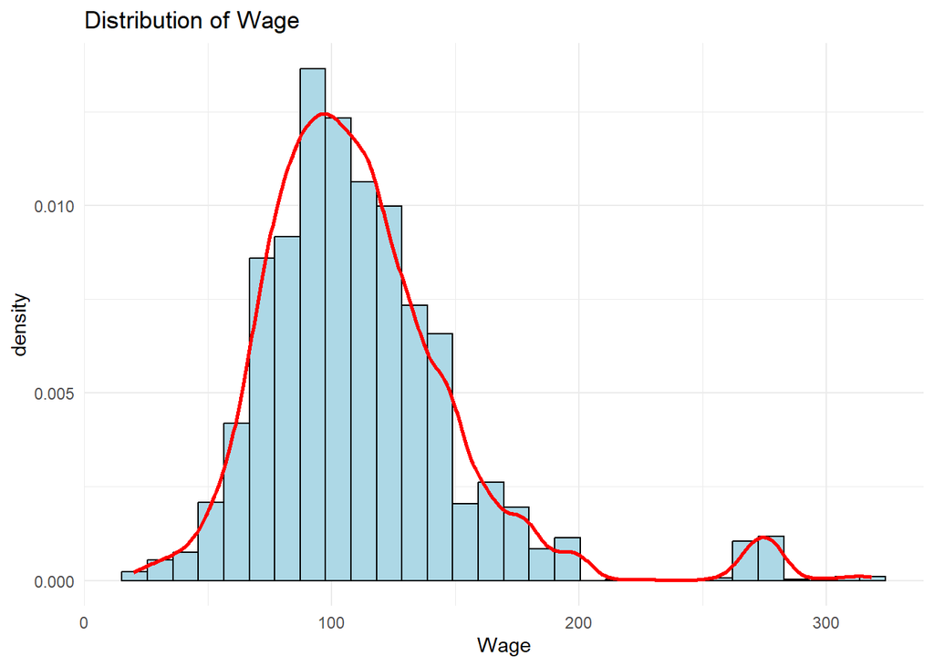

```r
ggplot(wage, aes(x = wage)) +
  geom_histogram(aes(y = ..density..), bins = 30, fill = "lightblue", color = "black") +
  geom_density(color = "red", lwd = 1) +
  labs(title = "Distribution of Wage", x = "Wage", x = "Density") +
  theme_minimal()
```

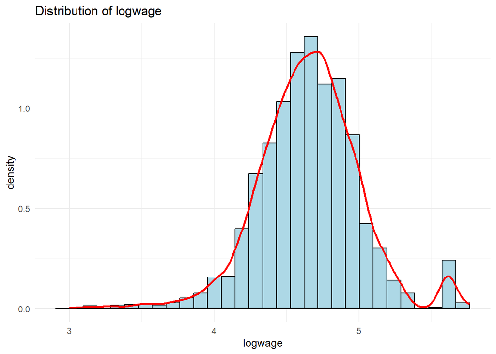

```r
ggplot(wage, aes(x = logwage)) +
  geom_histogram(aes(y = ..density..), bins = 30, fill = "lightblue", color = "black") +
  geom_density(color = "red", lwd = 1) +
  labs(title = "Distribution of logwage", x = "logwage", x = "Density") +
  theme_minimal()
```

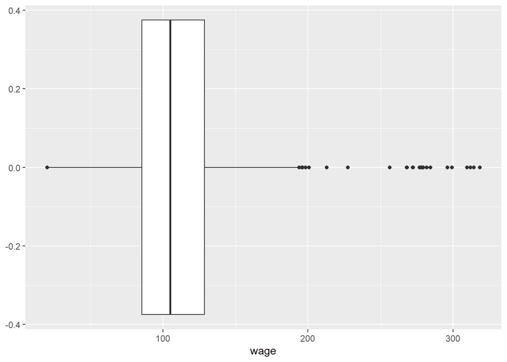

```r
wage |> ggplot(aes(wage)) + geom_boxplot()
```

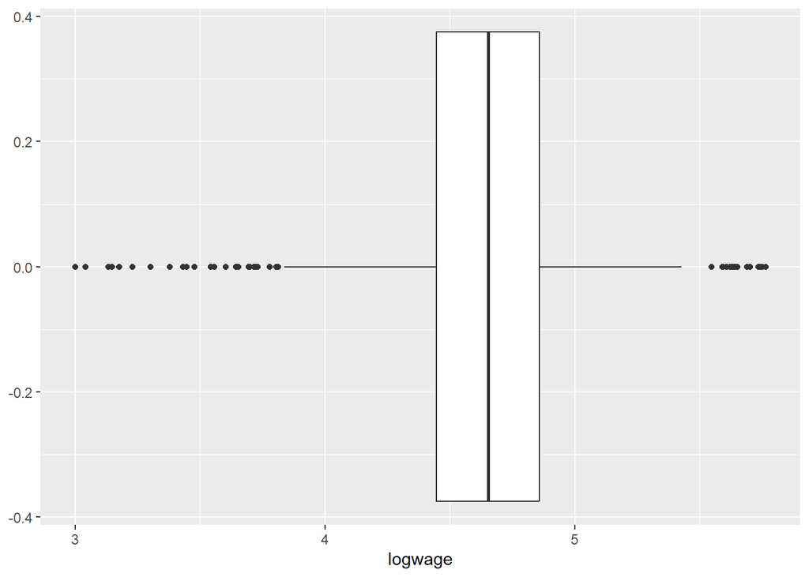

```r
wage |> ggplot(aes(logwage)) + geom_boxplot()
```

It does not seem like our target value follows a normal distribution!

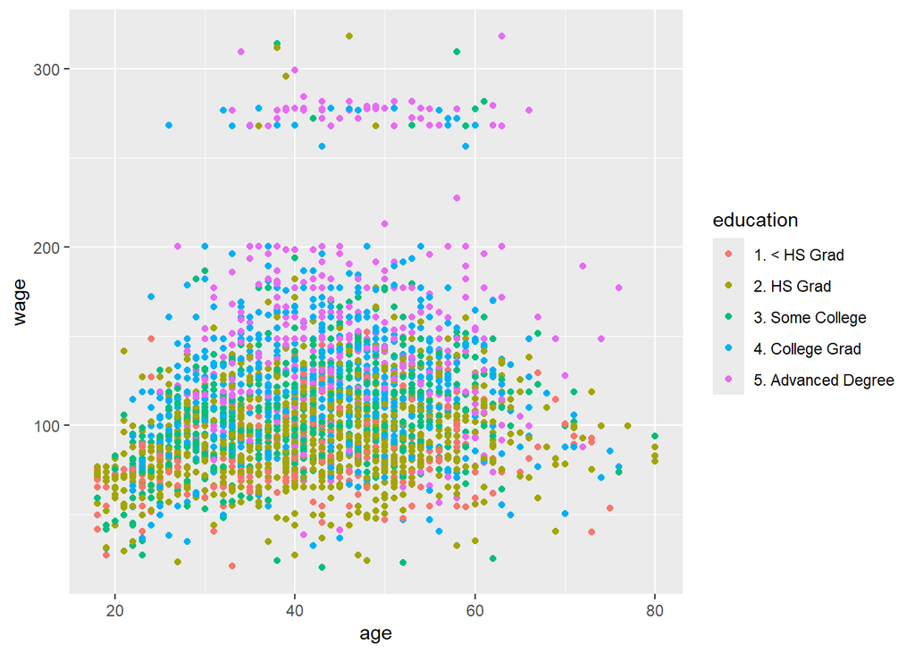

```r
wage |> ggplot(aes(x = age, y = wage, color = education)) +  geom_point()
```

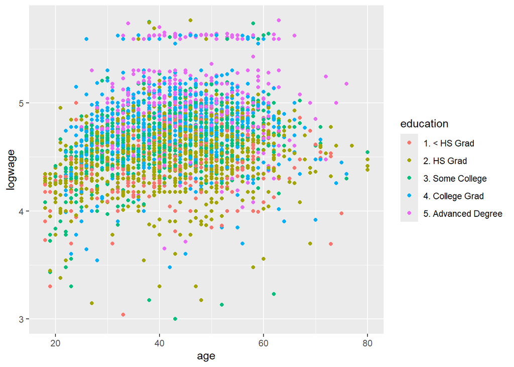

```r
wage |> ggplot(aes(x = age, y = logwage, color = education)) +  geom_point()
```

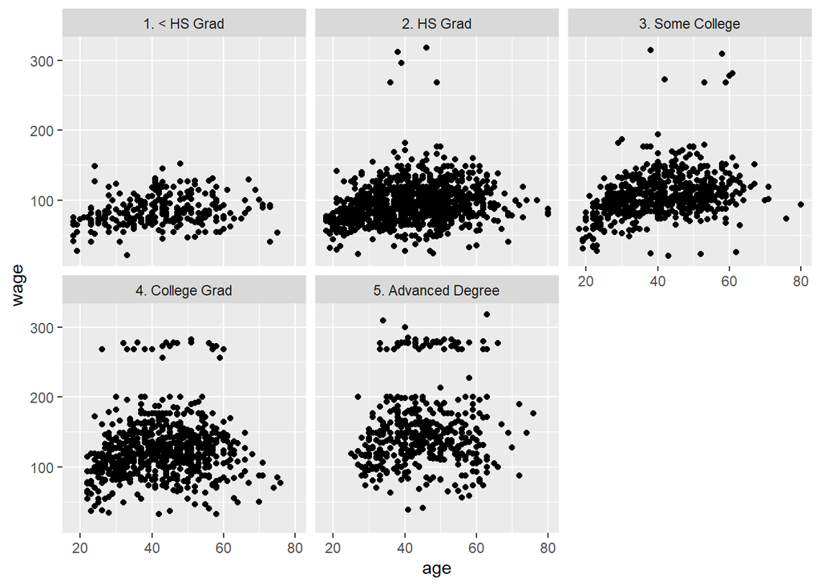

```r
ggplot(wage, aes(x = age, y = wage)) + geom_point() + facet_wrap(~education)
```

It seems like there are patterns in our data, a violation to assumption of iid random variables!

### Linear regression

```r
# check for no autocorrelation (independent residuals)
# Durbin-Watson test: Should be ~2 (if near 0 or 4, autocorrelation exists).
library(lmtest)
model <- lm(wage ~ age + education, data = wage)
dwtest(lm(wage ~ age + education, data = wage))
```

```
##
##  Durbin-Watson test
##
## data:  lm(wage ~ age + education, data = wage)
## DW = 1.9686, p-value = 0.1945
## alternative hypothesis: true autocorrelation is greater than 0
```

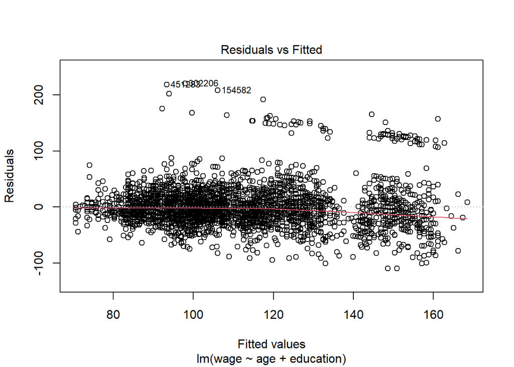

```r
plot(lm(wage ~ age + education, data = wage), which = 1)
```

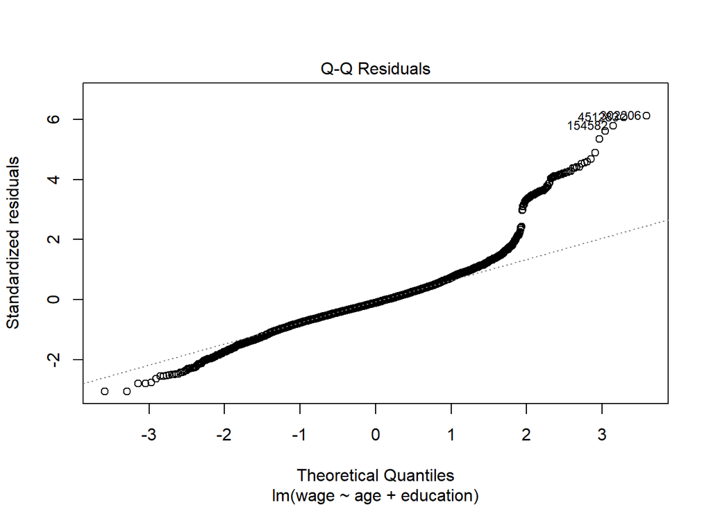

```r
plot(lm(wage ~ age + education, data = wage), which = 2)
```

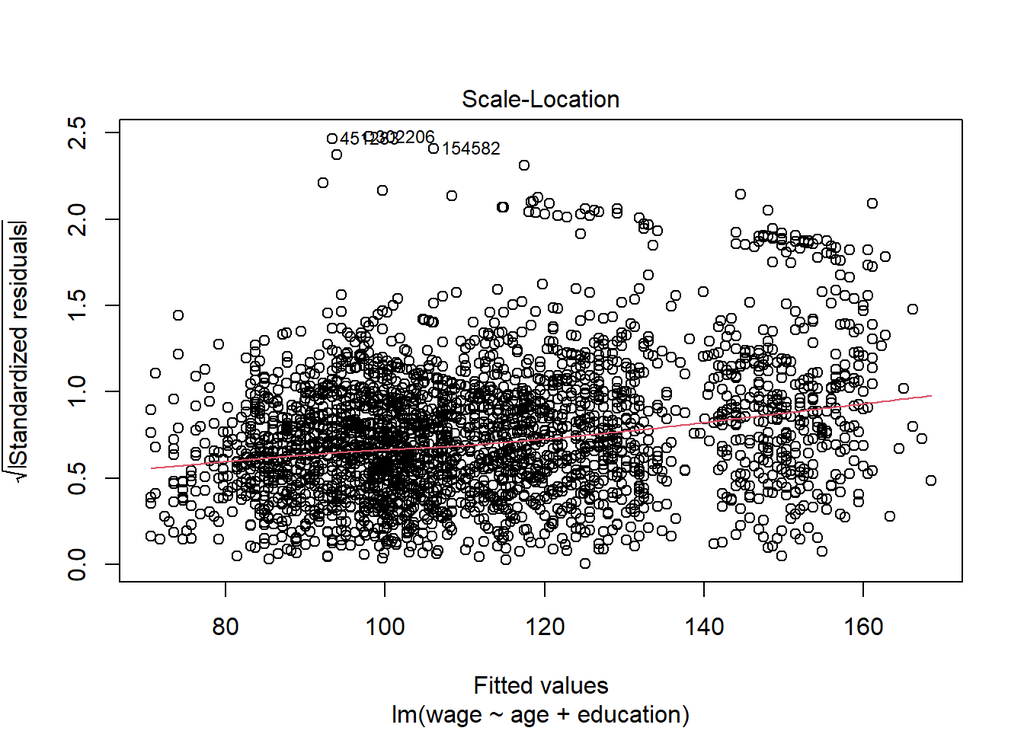

```r
plot(lm(wage ~ age + education, data = wage), which = 3)
```

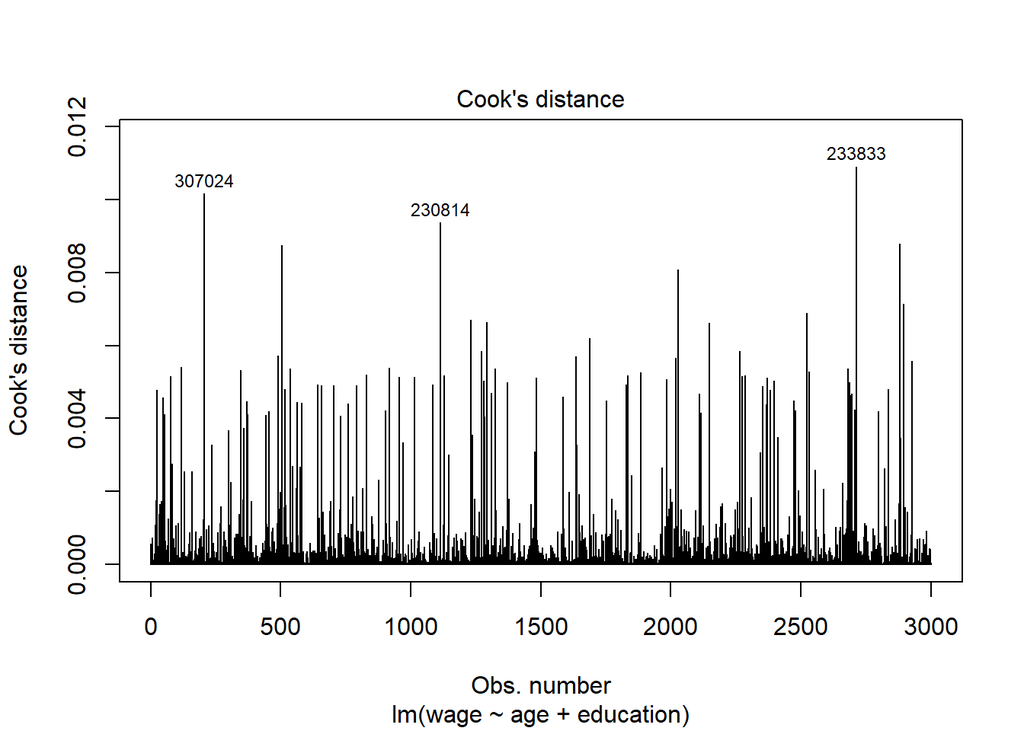

```r
plot(lm(wage ~ age + education, data = wage), which = 4)
```

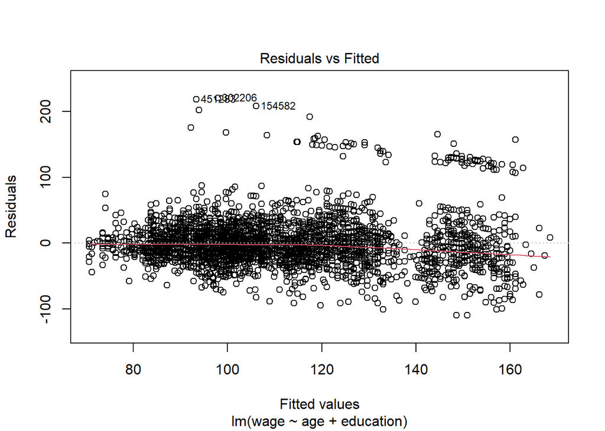

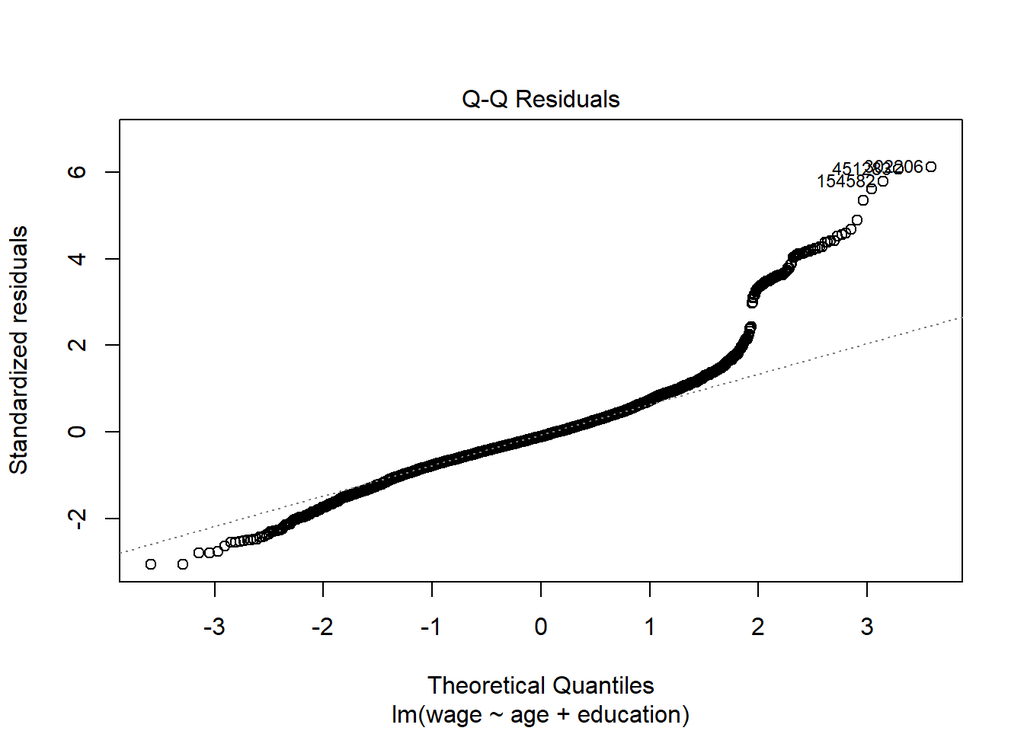

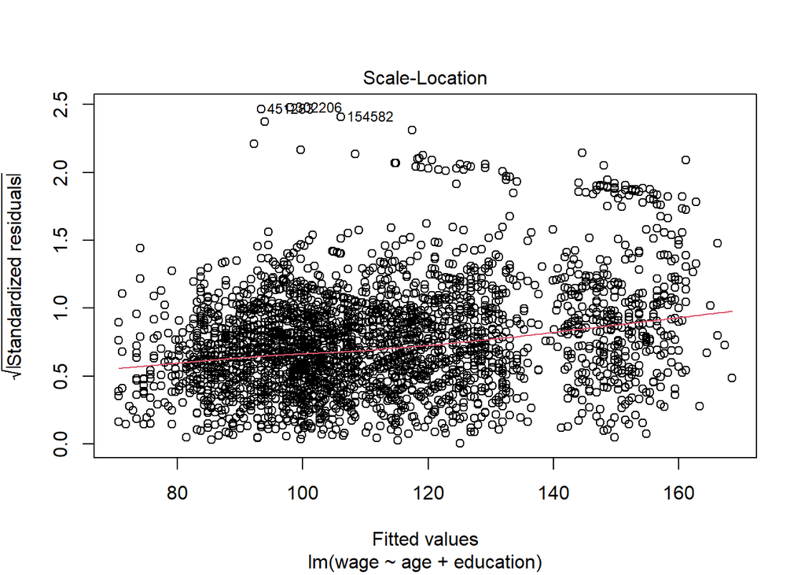

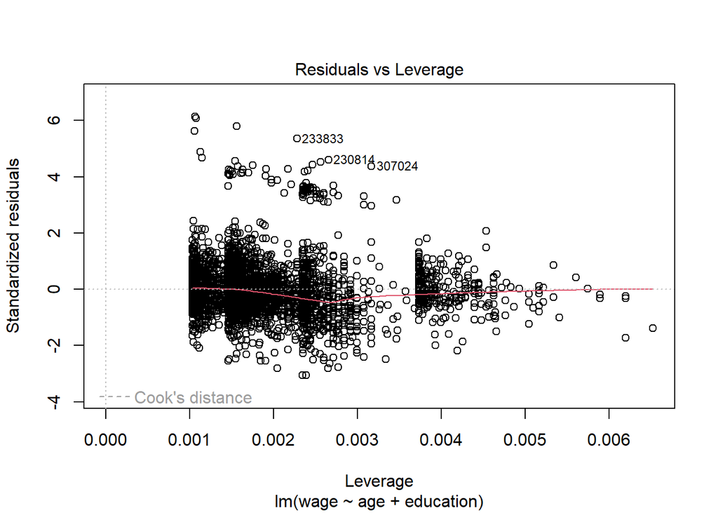

```r
# Diagnostic plots
plot(model, what = "wp")
```

### Quantile Regression

```r
# install.packages("quantreg")
library(quantreg)
wage$AgeGroup <- cut(wage$age, breaks = c(30, 40, 50, 60, 70), right = FALSE)
# wage[is.na(wage$AgeGroup),]
wage <- wage[complete.cases(wage), ]
wage |> dim()
```

```
## [1] 2517   12
```

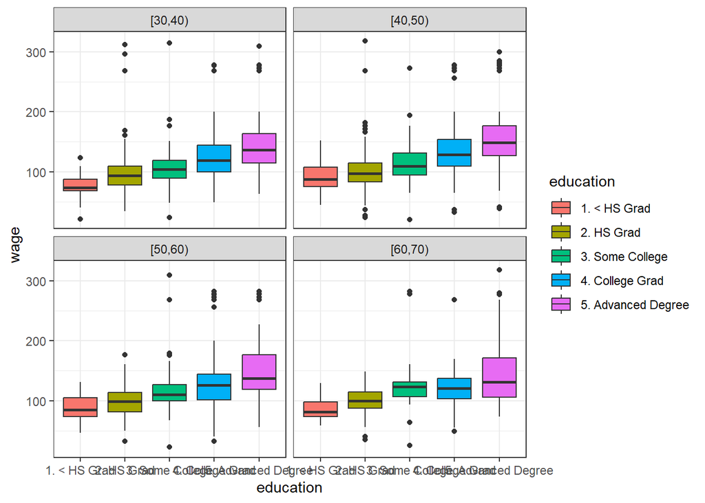

```r
# Create a subset of age groups and visualize wage distributions by education
ggplot(wage, aes(x = education, y = wage, fill = education)) +
  geom_boxplot() +
  facet_wrap( ~ AgeGroup) +
  theme_bw()
```

It seems that higher education levels generally associated with higher wages, which is reasonable.

```r
library(tidyr)
age_group <- wage |>
  filter(AgeGroup == "[30,40)")

# Fit quantile regression models for multiple taus
taus <- seq(0.1, 0.9, by = 0.1)
models <- rq(wage~education, data = age_group, tau = taus)
# Combine coefficients into a data frame for visualization
coefficients <- coef(models)
# coefficients add up
coefficients
```

```
##                              tau= 0.1 tau= 0.2 tau= 0.3 tau= 0.4 tau= 0.5
## (Intercept)                 62.398355 65.11085 68.74809 72.15046 73.77574
## education2. HS Grad          2.712499  9.93230 12.53517 15.83058 20.29697
## education3. Some College    17.456546 21.58430 25.32463 25.34284 31.14576
## education4. College Grad    25.582678 30.11986 36.17342 37.68353 45.10862
## education5. Advanced Degree 35.094939 46.61000 50.13627 50.93924 63.10062
##                             tau= 0.6 tau= 0.7 tau= 0.8  tau= 0.9
## (Intercept)                 81.28325 87.98103 94.07271 100.76427
## education2. HS Grad         18.40621 16.94047 20.40300  27.91622
## education3. Some College    28.55073 28.28429 29.01699  33.94110
## education4. College Grad    45.83249 50.31809 54.34044  63.88272
## education5. Advanced Degree 67.12991 68.52248 82.91694  99.77899
```

```r
coefficients_cumsum <- apply(coefficients, 2, cumsum) |>
  as.data.frame() |>
  # rows to column
  tibble::rownames_to_column(var = "education") |>
  pivot_longer(cols = starts_with("tau"),
               names_to = "tau",
               values_to = "quantile") |>
  mutate(tau = stringr::str_extract(tau, "[0-9.]+") |> as.numeric()) |>
  mutate(
    #replace (Intercept) with No Education and all "education" if it is there
    education = if_else(education == "(Intercept)", "1. No Grad", education),
    education = stringr::str_replace(education, "education", "")
  )

coefficients_cumsum
```

```
## # A tibble: 45 × 3
##    education    tau quantile
##    <chr>      <dbl>    <dbl>
##  1 1. No Grad   0.1     62.4
##  2 1. No Grad   0.2     65.1
##  3 1. No Grad   0.3     68.7
##  4 1. No Grad   0.4     72.2
##  5 1. No Grad   0.5     73.8
##  6 1. No Grad   0.6     81.3
##  7 1. No Grad   0.7     88.0
##  8 1. No Grad   0.8     94.1
##  9 1. No Grad   0.9    101.
## 10 2. HS Grad   0.1     65.1
## # ℹ 35 more rows
```

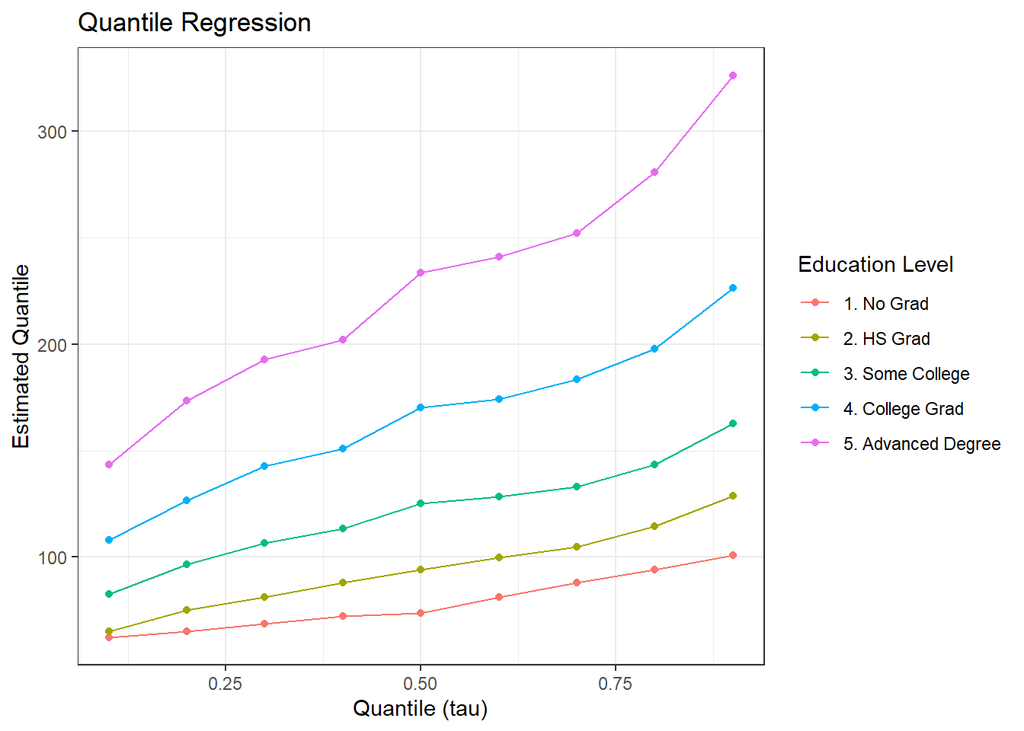

```r
# Visualization of coefficients
ggplot(coefficients_cumsum, aes(x = tau, y = quantile, color = education)) +
  geom_line() +
  geom_point() +
  theme_bw() +
  labs(
    title = "Quantile Regression",
    x = "Quantile (tau)",
    y = "Estimated Quantile",
    color = "Education Level"
  )
```

```r
# Check for crossing by comparing coefficients, it should be a monotonic relationship between all the quantile
coefficients_cumsum |>
  group_by(education) |>
  summarise(crossing = any(diff(quantile) < 0))
```

```
## # A tibble: 5 × 2
##   education          crossing
##   <chr>              <lgl>
## 1 1. No Grad         FALSE
## 2 2. HS Grad         FALSE
## 3 3. Some College    FALSE
## 4 4. College Grad    FALSE
## 5 5. Advanced Degree FALSE
```

What is here worth to mention is, that as the quantiles increase, the wage gap between individuals with different education levels becomes more pronounced. At the quantile 0.1 the gap are way smaller than at the quantile 0.9, the lines diverge significantly, showing that the wage disparity grows at higher income levels.

As there is no quantile crossing, these models are good fit for our dataset

# TODO: fit the other AgeGroup!

Let try modeling with GAMLSS!

### GAMLSS

```r
# Load the necessary package
library(gamlss)
model_gamlss <-
  gamlss(
    wage ~ education + age,
    sigma.formula = ~ education,
    family = NO,
    data = wage
  )
```

```
## GAMLSS-RS iteration 1: Global Deviance = 24967.93
## GAMLSS-RS iteration 2: Global Deviance = 24967.89
## GAMLSS-RS iteration 3: Global Deviance = 24967.89
```

```r
# gamlss(wage~education+age, sigma.formula = ~education+age, family = NO, data = wage) |> summary()

# Extend the model with smoothing terms
model_smooth <- gamlss(
  wage ~ cs(age) + education,
  sigma.formula = ~ education,
  family = NO,
  data = wage
)
```

```
## GAMLSS-RS iteration 1: Global Deviance = 24941.73
## GAMLSS-RS iteration 2: Global Deviance = 24941.46
## GAMLSS-RS iteration 3: Global Deviance = 24941.46
## GAMLSS-RS iteration 4: Global Deviance = 24941.46
```

```r
# Compare using AIC and BIC
AIC(model_gamlss, model_smooth)
```

```
##                    df      AIC
## model_smooth 14.00066 24969.47
## model_gamlss 11.00000 24989.89
```

```r
BIC(model_gamlss, model_smooth)
```

```
##                    df      BIC
## model_gamlss 11.00000 25054.03
## model_smooth 14.00066 25051.10
```

smooth_term does help fitting the model better w.r.t. AIC ! Let us then visualise it!

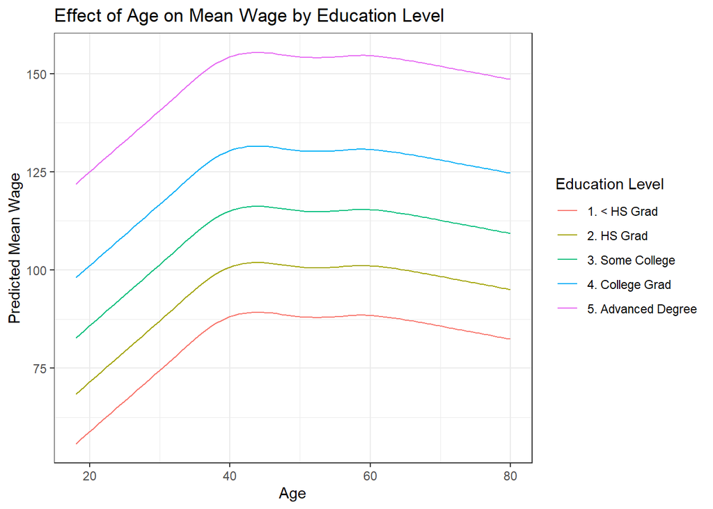

```r
# Create a grid of age and education
education_levels <- unique(Wage$education)
age_seq <- seq(min(Wage$age), max(Wage$age), length.out = 100)
prediction_grid <- expand.grid(age = age_seq,  education = education_levels)

# Add predictions for each combination
prediction_grid$mu <-
  predict(model_smooth, newdata = prediction_grid, what = "mu")

# Plot predictions for all education levels
ggplot(prediction_grid, aes(x = age, y = mu, color = education)) +
  geom_line() +
  theme_bw() +
  labs(
    title = "Effect of Age on Mean Wage by Education Level",
    x = "Age",
    y = "Predicted Mean Wage",
    color = "Education Level"
  )
```

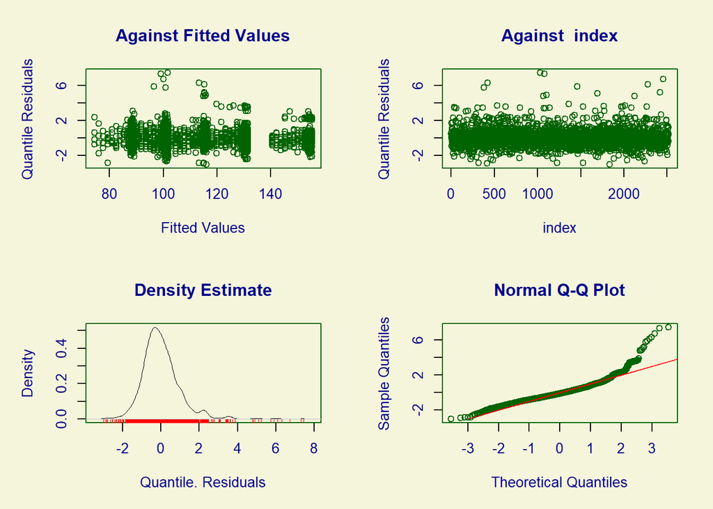

```
##        Summary of the Quantile Residuals
##                            mean   =  4.091283e-08
##                        variance   =  1.000398
##                coef. of skewness  =  1.538557
##                coef. of kurtosis  =  9.748474
## Filliben correlation coefficient  =  0.9551323
```

```r
# Diagnostic plots
plot(model_smooth, what = "wp")
```

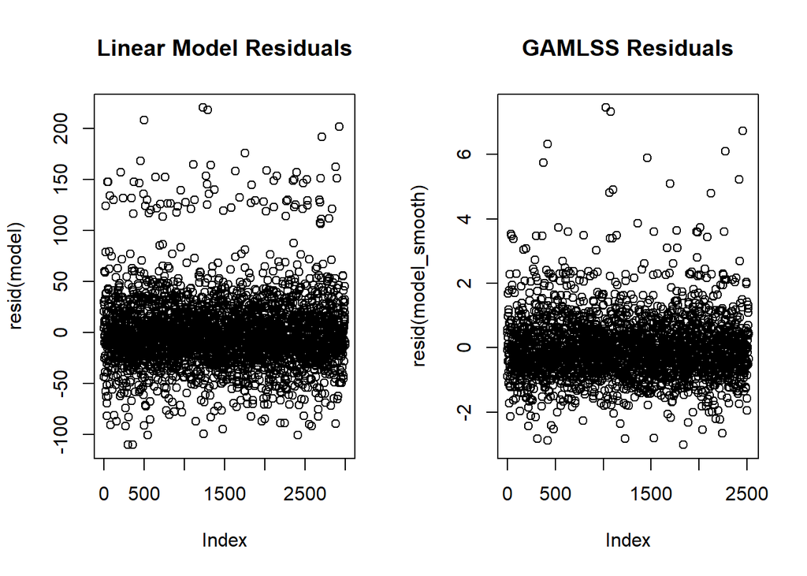

```r
# Compare residuals
par(mfrow = c(1, 2))
plot(resid(model), main = "Linear Model Residuals")
plot(resid(model_smooth), main = "GAMLSS Residuals")
```

Different Y-Axis Scales: The y-axis scale for the linear model is much larger because it measures raw residuals, which include systematic errors due to misspecification of the mean structure. In contrast, GAMLSS standardizes residuals relative to the fitted distribution (e.g., variance, skewness), resulting in smaller and comparable residuals.

### Evaluation with MSE

```r
# Partition the data.
set.seed(111)
train_index <- sample(1:nrow(wage), size = 0.75 * nrow(wage))
train <- wage[train_index,]
test <- wage[-train_index,]

# Predict on the test set.

# Predict on the test set using lm
lm_predictions <- predict(model, newdata = test)
model_smooth <- gamlss(
  wage ~ cs(age) + education,
  sigma.formula = ~ education,
  family = NO,
  data = test
)
```

```
## GAMLSS-RS iteration 1: Global Deviance = 6174.681
## GAMLSS-RS iteration 2: Global Deviance = 6172.906
## GAMLSS-RS iteration 3: Global Deviance = 6172.879
## GAMLSS-RS iteration 4: Global Deviance = 6172.878
## GAMLSS-RS iteration 5: Global Deviance = 6172.877
```

```r
model_not_smooth <- gamlss(
  wage ~ age + education,
  sigma.formula = ~ education,
  family = NO,
  data = test
)
```

```
## GAMLSS-RS iteration 1: Global Deviance = 6182.753
## GAMLSS-RS iteration 2: Global Deviance = 6182.069
## GAMLSS-RS iteration 3: Global Deviance = 6182.069
```

```r
# Compute MSE for lm
lm_mse <- mean((test$wage - lm_predictions) ^ 2)
# Compute MSE for the distributional regression model
distreg_predictions_smooth <-
  predictAll(model_smooth, newdata = test)

distreg_mse_smooth <-
  mean((test$wage - distreg_predictions_smooth$mu) ^ 2)
distreg_predictions <- predictAll(model_not_smooth, newdata = test)
distreg_mse <- mean((test$wage - distreg_predictions$mu) ^ 2)


# Compare the MSEs
cat("MSE for Linear Regression: ", lm_mse, "\n")
```

```
## MSE for Linear Regression:  1303.3
```

```r
cat("MSE for Distributional Regression: ", distreg_mse_smooth, "\n")
```

```
## MSE for Distributional Regression:  1271.929
```

```r
cat("MSE for Distributional Regression: ", distreg_mse, "\n")
```

```
## MSE for Distributional Regression:  1286.997
```